# Fundamentallösungen

## Stationäre Diffusion: Fundamentallösung der Laplce Gleichung $\Delta u=0 \ für \ {\displaystyle \mathbb {R} ^{n}}$

enstpricht der homogenen Poissongleichung $$u(x)=\Phi(x):= \left\{ \begin{array}{l} -\frac {1} {2 \pi} \ln {\|x\|}\ ,&n = 2\\ \frac {1} {\omega_n} \frac {1} {\|x\|^{n-2}}=\frac {3} {4 \pi} \frac {1} {\|x\|^{n-2}}\ ,&n \geq3\\ \end{array} \right.$$ wobei ${\omega_n}$ den Volumen der Einheitskugel in ${\displaystyle \mathbb {R} ^{3}}$ beschreibt und $\|\cdot \|$ die Vektornorm in $\mathbb{R}^n$ ist, vergleiche

[https://de.m.wikipedia.org/wiki/Laplace-Gleichung#Lösung_der_Laplace-Gleichung| ] .

### Implementation der Fundamentallösung für ${\displaystyle \mathbb {R} ^{2}}$

Im Nullpunkt erreicht die Fundamentallösung einen Singularitätspunkt:  
$\lim_{x\to 0} \Phi(x)=\infty$  
Dieser wird im Definitionbereich ausgeschnitten.

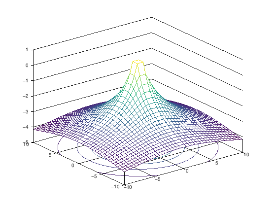

```matlab
scale = 10;
step = 0.5;
x=[-scale:step:0-step, 0+step:step:scale]; % Zeilen laufen von -10 bis 10
y=[-scale:step:0-step, 0+step:step:scale]; % Spalten laufen von -10 bis 10

[x,y]=meshgrid (x,y); % verbindet x und y zu einer Matrix, so dass ein Punktegitter entsteht

norm = sqrt(x.^2+y.^2); %norm gibt für jeden Eintrag der 10x10 Matrix den Abstand zum Ursprung an.

z=(-1/2*pi)*log(norm); % gibt unsere Fundamentallösung für die stationäre Laplace Gleichung an für R^2

meshc(x,y,z) %plottet unsere Funktion im Dreidimensionalen
```

##### Ergebnis

- Lösung zeigt die Verteilung der Teilchen im Raum.
- Da es sich um eine homogene Diffusion handelt, findet nur Diffusion statt und keine Reaktion. Daher kein geeignetes Modell für Corona-Modellierung.
- Nach dem Erhaltungsgesetz bleibt bleibt der "Stoff" erhalten, da nichts hinzugefügt oder entfernt wird.

## Homogene instationäre Diffusionsgleichung für konstanten Diffusionskoeffizienten $c(x)\equiv a \in \mathbb R$

### $\partial_t u -a\Delta u=0$

Fundemantlösung:  
$u ({x},t)=\Psi ({x},t)=\frac{1}{(4\pi a t)^{n/2}} \exp \left(-\frac{\|{x}\|^2}{4at}\right)$  
wobei $\textstyle \|{x}\|^2 = \sum_{k=1}^n x_k^2$ das Quadrat der Euklidische Norm|euklidischen Norm von ${x}$ ist

### Implementation der Fundamentallösung für ${\displaystyle \mathbb {R} ^{2}}$

Im Nullpunkt erreicht die Fundamentallösung einen Singularitätspunkt:  
$\lim_{({x},t)\to (0,0)} \Psi(x)=\infty$  
Dieser wird im Definitionbereich ausgeschnitten.

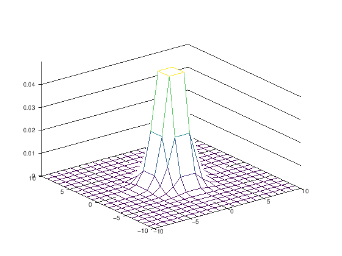

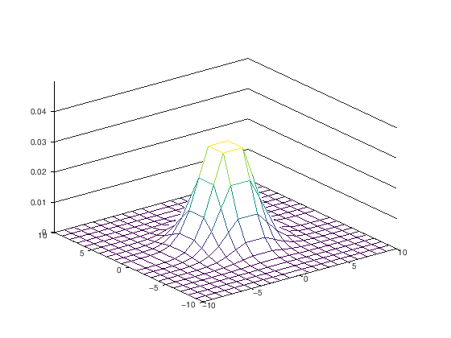

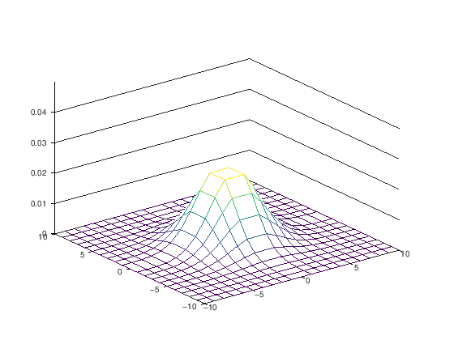

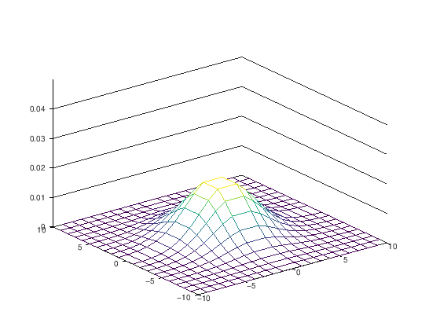

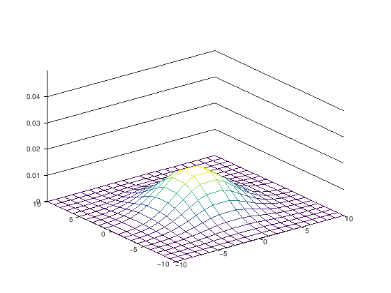

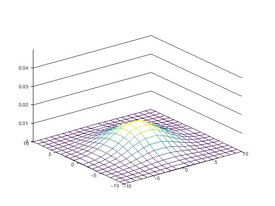

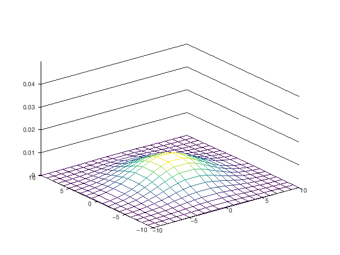

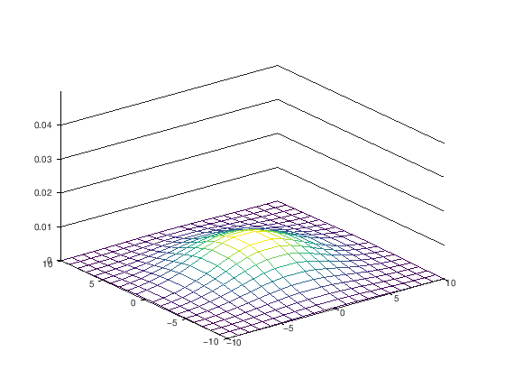

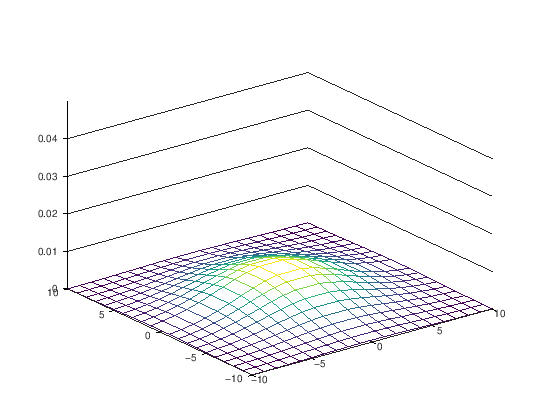

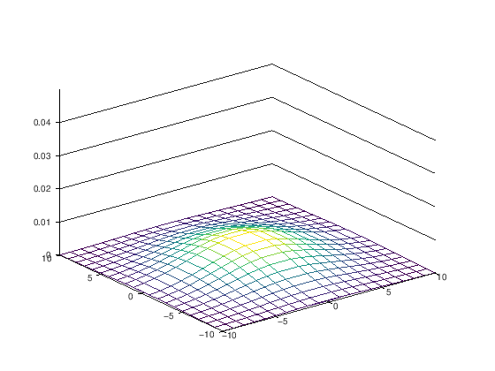

```matlab
scale = 10;
step = 1;
x=[-scale:step:0-step, 0+step:step:scale]; % Zeilen laufen von -10 bis 10
y=[-scale:step:0-step, 0+step:step:scale]; % Spalten laufen von -10 bis 10
a=1;


[x,y]=meshgrid (x,y); % verbindet x und y zu einer Matrix, so dass ein Punktegitter entsteht

norm = sqrt(x.^2+y.^2); %norm gibt für jeden Eintrag der 10x10 Matrix den Abstand zum Ursprung an.

for t=1:10
 z= (1/(4*pi*a*t))*(exp(-norm.^2/(4*a*t))); % z gibt uns die Fundamtenallösung für unsere homogene (instationäre) Diffusionsgleichung an
  figure(t) %gibt die einzelnen Bilder aus zu den einzelnen Zeitpunkt von t=1 bis t=10
  meshc(x,y,z) %plottet unsere Funktion im Dreidimensionalen
  axis([-scale scale -scale scale 0 0.05])
endfor
```

##### Ergebnis

- Lösung zeigt die Verteilung der Teilchen im Raum.
- Nach dem Fick'schen Gesetz diffundieren die Teilchen vom Ort höherer Konzentration in Orte niedriger Konzentration.
- Da es instationäre ist, erkennt man die Brown'sche Bewegung.
- Da es sich um eine homogene Diffusion handelt, findet nur Diffusion statt und keine Reaktion. Daher kein geeignetes Modell für Corona-Modellierung.
- Nach dem Erhaltungsgesetz bleibt bleibt der "Stoff" erhalten, da nichts hinzugefügt oder entfernt wird.